# Neural Networks

Author

Simone Brazzi

# 1 Theory

## 1.1 The Perceptron

Bio inspired model, the brain neurons. The functioning is different, be aware!

The **neuron** is the transistor of the brain.

- **x** -> input layer or action potential.
- **node** -> activatio function gets the threshold value.

This is the **perceptron**

$$ z = x_i*w_i

y = (z) $$

## 1.2 Activation Function

This are what makes possibile to get non linear or complex relations in data.

### 1.2.1 Step functions

$$\begin{array}{rcl}
{1} & \mbox{if} & z \ge 0 \\
{0} & \mbox{if} & z < 0
\end{array}$$

## 1.3 Sigmoid

```r
library(tidyverse)
sigmoid <- function(z){
  1 / (1 + exp(-z))
}

x = seq(-10, 10, 1)
y = sigmoid(x)

x
```

```
 [1] -10  -9  -8  -7  -6  -5  -4  -3  -2  -1   0   1   2   3   4   5   6   7   8
[20]   9  10
```

```r
y
```

```
 [1] 4.539787e-05 1.233946e-04 3.353501e-04 9.110512e-04 2.472623e-03
 [6] 6.692851e-03 1.798621e-02 4.742587e-02 1.192029e-01 2.689414e-01
[11] 5.000000e-01 7.310586e-01 8.807971e-01 9.525741e-01 9.820138e-01
[16] 9.933071e-01 9.975274e-01 9.990889e-01 9.996646e-01 9.998766e-01
[21] 9.999546e-01
```

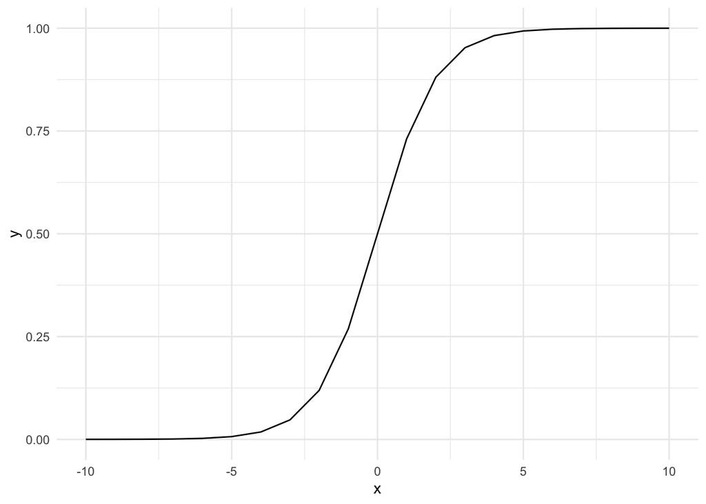

```r
df <- tibble(x = x, y = y)
ggplot(df, aes(x, y)) +
  geom_line() +
  theme_minimal()
```

$$\phi(z) = \frac{1}{1+e^{-z}}$$

It lets compress a value betwene [0, 1], as a probability.

### 1.3.1 ReLU

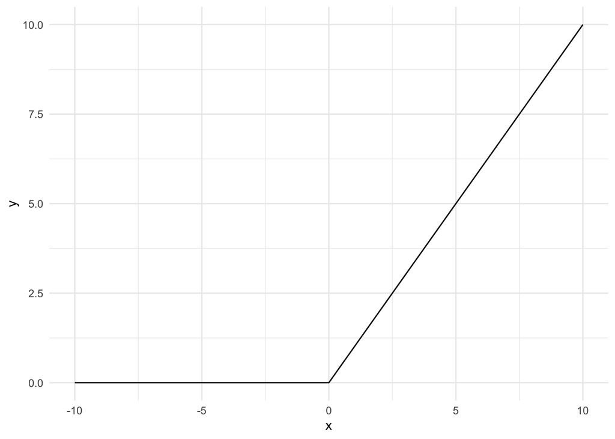

```r
library(tidyverse)

relu <- function(z) {
  pmax(0, z)
}

x <- seq(-10, 10, 1)
y <- relu(x)
df <- tibble(x = x, y = y)
ggplot(df, aes(x, y)) +
  geom_line() +
  theme_minimal()
```

$$\phi(z) = \max(0, z)$$

### 1.3.2 tanh

hyperbolic tangent. It different from the sigmoid because values are between [-1, 1].

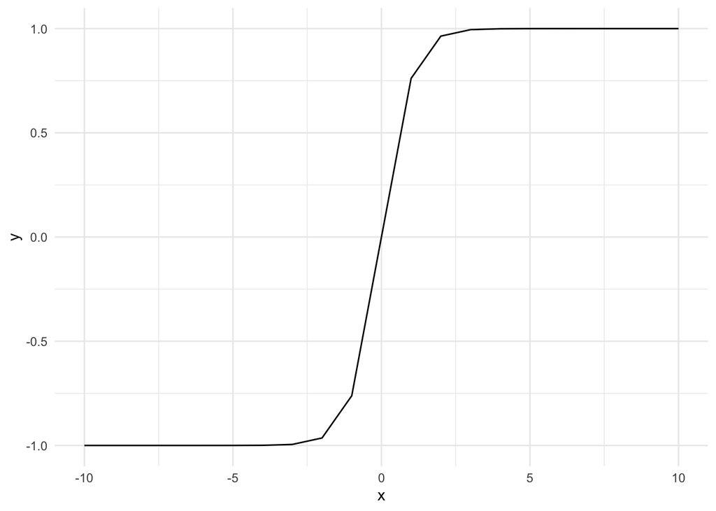

```r
library(tidyverse)

tanh <- function(z){
  (1 - exp(-2*z)) / (1 + exp(-2*z))
}

x <- seq(-10, 10, 1)
y <- tanh(x)
df <- tibble(x = x, y = y)
ggplot(df, aes(x, y)) +
  geom_line() +
  theme_minimal()
```

$$\phi(z) = \frac{1-e^{-2z}}{1 + e^{-2z}}$$

Typically the **perceptron** uses the **step function**. If we use the **sigmoid**, we have the **logistic regression**.

## 1.4 Multilayer Perceptron

**Vanilla Neural Network**. It is and ensembled model, meaning it is composed from lots of perceptron. It is the most know example.

### 1.4.1 Input layer

Normalized features. Each feature is associated with a weight and return an output. This is a simple perceptron. If you do this with different weights, you obtain differents outputs.

Each outputs now is an input for the logistic regression. Each new input is multiplied by its weight.

### 1.4.2 Hidden layer

The NN use the input features to create new ones which are more usefule. This is **feature engineering** done by the NN instead of by the data scientist.

these new features are used to obtain the output layer.

### 1.4.3 What’s the problem?

The **hyperparameters** has to be optimized. For example, the number of nodes and how many nodes in the model has to be optimized, with the risk of overfitting.

### 1.4.4 Deep Learning

Deep Neural Networks, meaning lots of layers or lots of perceptron.

The activation function lets everything works, otherwise it is just multiplication and summation. The activation function lets implement non linearity.

The most used ones are the **relu** for the hidden layers. For the output layer: - **sigmoid** for a binary classification. - **softmax** for a multi class classification. - **identity** for a linear regressoin.

### 1.4.5 Pros and Cons

**PROs** - It learns complex relations. - The more data the better performance.

**CONs** - It needs lots of data. - Computational savvy. - Lots of hyperparameters. - The more complex the NN the more it is hard to explain.

### 1.4.6 When to use MLP

- Simpler models don’t work.
- You uhave lots of data.
- New data flow over time to improve the model.
- Lots of computational power.
- Model explainability is not the most important point.

## 1.5 How a MLP is Trained

Optimization algorithm:

- Gradient Descent.
- RProp and RMProp
- Adadelta
- AdaGrad
- AdaMax
- ADAM

In a DNN, the gigantic number of weights complicates the process. How much a single weight inluence the error is not as simple. The algorithm used for this is the **backpropagation**: whilst the model calculate the prediction with the **forwardpropagation**, the error is used to to how much each layer influce the error. This information is expressed as a weight update.

## 1.6 Universarl Approximation Theorem

An MLP with a single hidden layer and a big enough number of perceptron can approximate every continuous function with every precision level. This is true if: - It approximate a **continuous function**. - The activation funcion is the right one.

**Warning**

not just the ones with one hidden layer, but all the MLP have this property.

MLP as an **universal approximation** of a continuous function.

# 2 Practice

## 2.1 Dataset

```python
import numpy as np
import matplotlib.pyplot as plt
from sklearn.preprocessing import MinMaxScaler
from sklearn.model_selection import train_test_split
from sklearn.datasets import make_moons

import numpy as np
import matplotlib.pyplot as plt
import seaborn as sns


def plot_decision_boundary(model, train_set, test_set, sv=None):

    #plt.figure(figsize=figsize)

    if(model):
        X_train, Y_train = train_set
        X_test, Y_test = test_set
        X = np.vstack([X_train, X_test])
        x_min, x_max = X[:, 0].min() - .5, X[:, 0].max() + .5
        y_min, y_max = X[:, 1].min() - .5, X[:, 1].max() + .5

        xx, yy = np.meshgrid(np.arange(x_min, x_max, .02),
                             np.arange(y_min, y_max, .02))

        if hasattr(model, "predict_proba"):
            Z = model.predict_proba(np.c_[xx.ravel(), yy.ravel()])[:, 1]
        else:
            Z = model.predict(np.c_[xx.ravel(), yy.ravel()])

        Z = Z.reshape(xx.shape)

        plt.contourf(xx, yy, Z, alpha=.8)

    plt.scatter(X_train[:,0], X_train[:,1], c=Y_train)
    plt.scatter(X_test[:,0], X_test[:,1], c=Y_test, alpha=0.6)

    if sv is not None:
      plt.scatter(sv[:, 0], sv[:, 1], facecolors="none", edgecolor='white', s=100)

    plt.show()
```

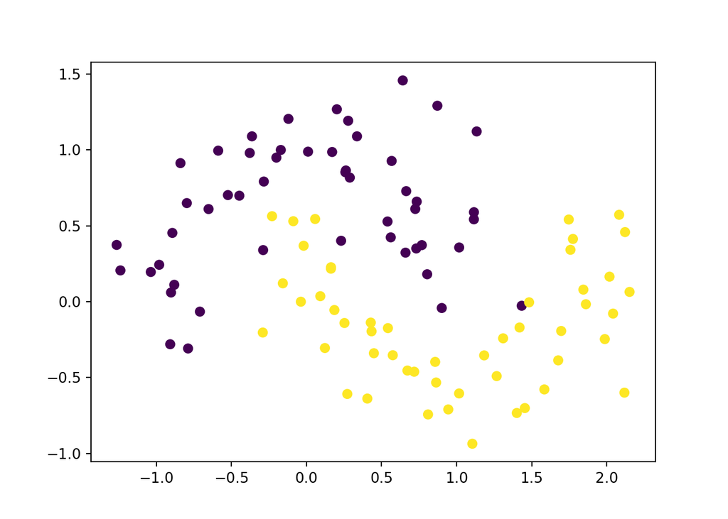

```python
random_seed = 0

x, y = make_moons(n_samples=100, noise=.25, shuffle=True, random_state=random_seed)

plt.scatter(x[:, 0], x[:, 1], c=y)
plt.show()
```

## 2.2 Preprocessing

```python
xtrain, xtest, ytrain, ytest = train_test_split(
  x, y,
  test_size=.2,
  random_state=random_seed
)
```

```python
mms = MinMaxScaler()
xtrain= mms.fit_transform(xtrain)
xtest = mms.transform(xtest)

xtrain.min(), xtrain.max()
```

```
(np.float64(0.0), np.float64(1.0))
```

## 2.3 Models

### 2.3.1 Perceptron

Simplest method

```python
from sklearn.linear_model import Perceptron
```

Most of the parameters are the same of a linear regression. What is different is the activation function: in the linear regression is the sigmoid, here is the step function.

```python
perceptron = Perceptron()
perceptron.fit(xtrain, ytrain)
```

```
Perceptron()
```

```python
perceptron.score(xtest, ytest)
```

```
0.85
```

`Perceptron` has the `.score()` method, not the `evaluate()`.

Even if the score is high, it is better to check the decision boundary.

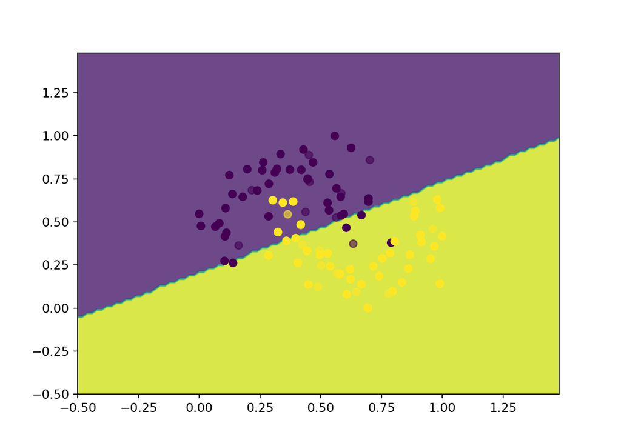

```python
plt.close()
plot_decision_boundary(perceptron, (xtrain, ytrain), (xtest, ytest))
```

The separation is clean: the perceptron output is 0/1, because it is using the **step function**. So, the model is not performing as we want.

### 2.3.2 Logistic Regression

```python
from sklearn.linear_model import LogisticRegression
```

Most of the parameters are the same of the Perceptron, so the class separation is expected to be similar.

```python
lr = LogisticRegression()
lr.fit(xtrain, ytrain)
```

```
LogisticRegression()
```

```python
lr.score(xtest, ytest)
```

```
0.85
```

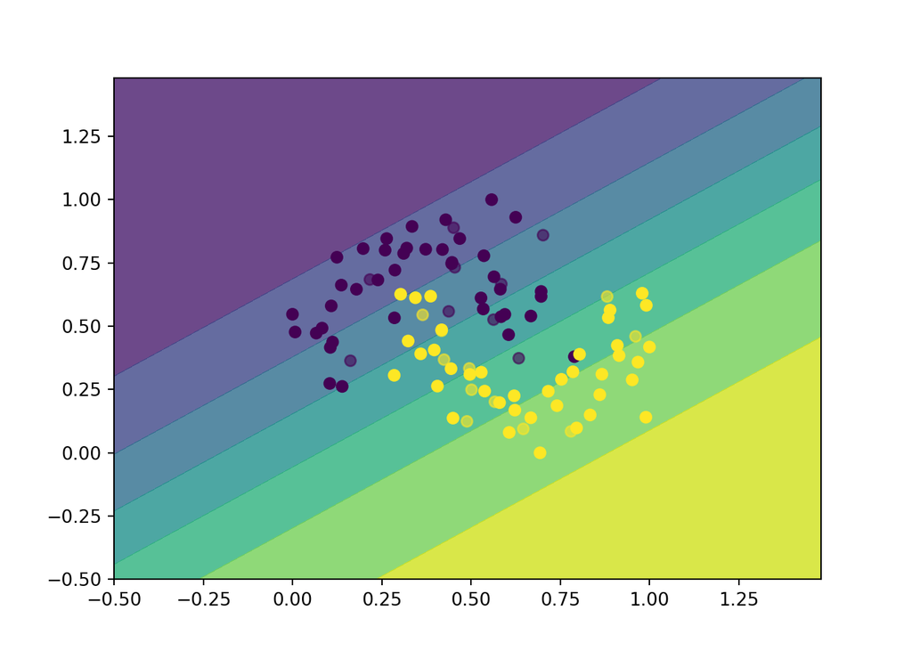

```python
plot_decision_boundary(lr, (xtrain, ytrain), (xtest, ytest))
```

The sigmoid return the probability of the class. Ignoring it, the main discrimination is almost the same of the Perceptron. This is confirmed by the 0.85 accuracy and the bias intercept on the y axis.

### 2.3.3 Multilayer perceptron

```python
from sklearn.neural_network import MLPClassifier
```

The `hidden_layer_sizez` accept a tuple, but with a comma at the end.

```python
mlp = MLPClassifier(
  hidden_layer_sizes=(100, 100, 100,),
  random_state=42
)
mlp.fit(xtrain, ytrain)
```

```
MLPClassifier(hidden_layer_sizes=(100, 100, 100), random_state=42)
```

```python
mlp.score(xtest, ytest)
```

```
0.9
```

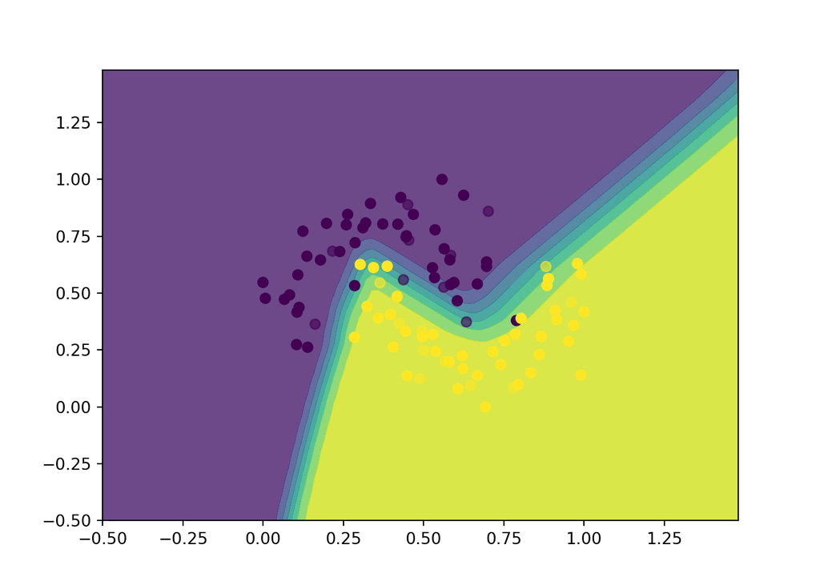

```python
plot_decision_boundary(mlp, (xtrain, ytrain), (xtest, ytest))
```

The model is much more able to capture the non linearity, so much so that the probabilities are concentraded close to the separation line.

### 2.3.4 Layer exploration

This is useful to check why a MLP is so complicated.

```python
type(mlp.coefs_)
```

```
<class 'list'>
```

```python
len(mlp.coefs_)
```

```
4
```

The len depends on input + 3 hidden layers.

THe weights between input and first hidden layer.

```python
mlp.coefs_[0]
```

```
array([[ 5.26926453e-02,  4.47981850e-01,  1.55299707e-02,
        -3.62826568e-02, -1.08926370e-01, -4.45087169e-02,
        -7.75715046e-02,  2.54068290e-01,  6.51453001e-04,
         1.10966719e-02, -2.29282716e-01,  2.36195546e-01,
         2.65259748e-01, -2.84318654e-02, -1.34334914e-01,
        -3.63585496e-02,  9.18453622e-03, -4.15463910e-02,
        -3.03802929e-02, -1.29279977e-01,  1.26184012e-01,
        -1.09361243e-01, -1.10597849e-02, -2.23534263e-03,
         5.73983924e-06,  1.26115206e-01, -1.14272958e-01,
         7.43426803e-02,  4.79662875e-02, -3.91882545e-01,
        -1.09557632e-02, -4.01161221e-02, -1.63556592e-01,
         2.04222606e-01,  3.43782835e-01,  1.70603489e-01,
        -9.04773285e-03, -6.35632921e-02,  4.57804808e-02,
         1.28490525e-01, -1.98897395e-01, -4.48155043e-02,
        -2.23114918e-01,  2.37640642e-01, -1.74292476e-02,
         8.68764499e-02, -7.99636635e-03, -1.12798373e-01,
         1.54919722e-02, -3.13510055e-01,  3.71145567e-01,
         1.11385287e-01,  2.34519678e-01,  3.56434690e-01,
         2.37764664e-01,  2.14354905e-01, -2.20078085e-01,
        -1.29010514e-01, -2.30170107e-01, -6.17339471e-03,
        -2.52416784e-01, -5.18277434e-02,  3.76111782e-01,
        -8.08764962e-02, -3.04502995e-01,  7.27012023e-02,
        -3.52722679e-01,  1.54656840e-01, -7.16531214e-02,
         3.57483527e-01,  1.35069688e-01, -3.62093677e-01,
        -1.83994447e-01,  1.00012468e-01,  1.23435764e-01,
         1.36146621e-01,  1.79144412e-01, -3.36182021e-01,
        -6.07533310e-02, -4.07432811e-01,  1.89401020e-01,
         1.59730003e-03,  4.17998693e-02, -7.55901677e-02,
        -2.51668588e-01, -6.19169539e-03,  1.24470098e-01,
         1.05671749e-01,  2.45027604e-01, -2.56403314e-02,
        -5.61564966e-02,  5.27865479e-02,  2.97595304e-01,
         2.10028434e-01,  2.42151958e-02, -1.42998967e-02,
         1.01586973e-01,  1.08717884e-01, -1.37576149e-01,
        -6.00767885e-02],
       [-3.01152714e-01,  1.11399518e-01, -7.62223494e-03,
         9.39119500e-03,  2.50684412e-01, -1.94866602e-02,
        -3.56516333e-04,  8.96159853e-02, -2.42725243e-02,
        -7.07906872e-02,  5.98652794e-03, -2.01798678e-01,
         1.96837811e-01,  3.39604266e-02,  1.14927936e-01,
         5.32148625e-02,  1.97137642e-01, -1.40099603e-01,
```

[output cut: 13 more lines]

```
         1.73213425e-01, -1.11661724e-02,  1.47820183e-02,
        -2.52782594e-02,  1.35637784e-01,  1.19137789e-01,
        -1.60889345e-04, -1.46570794e-01,  1.74459240e-01,
        -5.29587371e-02, -1.92904639e-01, -8.39203035e-02,
        -5.59603312e-03,  1.31778893e-01, -1.18690903e-01,
         6.06735835e-02, -9.32887215e-02,  2.41260351e-02,
        -7.39741898e-02,  9.58906241e-02, -2.55426122e-02,
         2.26124151e-01, -9.93371359e-02, -1.20775448e-01,
        -5.81969663e-02,  2.37654383e-01,  5.51426133e-02,
        -3.89032222e-02,  4.49731570e-03,  1.91444994e-01,
         6.22924825e-02,  1.90729609e-02, -7.05353632e-02,
        -6.51404229e-02,  2.62076102e-01,  1.70197488e-01,
         5.59812553e-02, -4.60044208e-03, -7.86391005e-02,
         1.31344192e-01,  2.28503377e-01,  2.32305696e-01,
         2.64309463e-02]])
```

Whilst the bias are

```python
mlp.intercepts_[0]
```

```
array([ 0.07238612, -0.33815359, -0.16413418,  0.21432496,  0.08681652,
       -0.2380744 , -0.1933147 ,  0.13040014, -0.2400804 , -0.16453226,
        0.07664378,  0.16724577,  0.10477962, -0.13374903,  0.11866188,
       -0.12745291, -0.02353611,  0.08603781,  0.04138822,  0.12445051,
        0.11732054,  0.04630926, -0.19709669, -0.06416726, -0.11389358,
       -0.13620307,  0.28466676, -0.02598962,  0.2603787 ,  0.14465761,
        0.19665721,  0.00127918,  0.07415706,  0.06197456, -0.18307137,
        0.17364419, -0.10634102, -0.23074065,  0.12648685, -0.11517254,
        0.15585626,  0.2763557 ,  0.24686421,  0.02166756, -0.23503806,
        0.27446276, -0.0348358 ,  0.20628223,  0.31489725,  0.13779258,
       -0.17982906, -0.07806578,  0.23758294, -0.24610214, -0.15775152,
        0.08979514,  0.18917457,  0.0942449 ,  0.08605229, -0.1953981 ,
        0.10372305,  0.30442635, -0.29986605, -0.0095113 ,  0.28241558,
        0.12998147,  0.14769872,  0.16881799, -0.0681568 , -0.21383188,
        0.21616711,  0.18430825,  0.21953324,  0.27743642,  0.02484237,
        0.0627368 ,  0.21367033,  0.13064005,  0.0541127 ,  0.18562658,
        0.25464851, -0.07858389, -0.01940413, -0.19694769,  0.10914711,
       -0.22510106,  0.00649672,  0.05482643, -0.01268846,  0.11446658,
       -0.22774083, -0.20539682,  0.15827033, -0.07913485, -0.18090222,
       -0.00055302,  0.16058243, -0.09939567,  0.09885145, -0.20113602])
```

```python
weights = 0
for i in range(len(mlp.coefs_)):

  coefs = mlp.coefs_[i].size #.shape[0 as np.arrays]
  bias = mlp.intercepts_[i].size

  tot = coefs+bias

  print(f"Layer {i} => Weights {coefs} Bias {bias} Totale {tot}")

  weights += tot
```

```
Layer 0 => Weights 200 Bias 100 Totale 300
Layer 1 => Weights 10000 Bias 100 Totale 10100
Layer 2 => Weights 10000 Bias 100 Totale 10100
Layer 3 => Weights 100 Bias 1 Totale 101
```

```python
print(f"Total coefficients of the NN {weights}")
```

```
Total coefficients of the NN 20601
```

Layer 0: 200 weights, 100 bias. 2 features, 100 neurons. Layer 1/2: 100 neurons connected to 100 neurons, with 100 bias. 10100. Layer 3: 100 neurons connected to 1 output, 1 bias, 101.

The best practice is Tensorflow/Keras or PyTorch.

## 2.4 Activation function

Lets remove it with the identity function.

```python
mlp = MLPClassifier(
  hidden_layer_sizes=(100,)*10,
  activation="identity",
  random_state=random_seed
)
mlp.fit(xtrain, ytrain)
```

```
MLPClassifier(activation='identity',
              hidden_layer_sizes=(100, 100, 100, 100, 100, 100, 100, 100, 100,
                                  100),
              random_state=0)
```

```python
mlp.score(xtest, ytest)
```

```
0.85
```

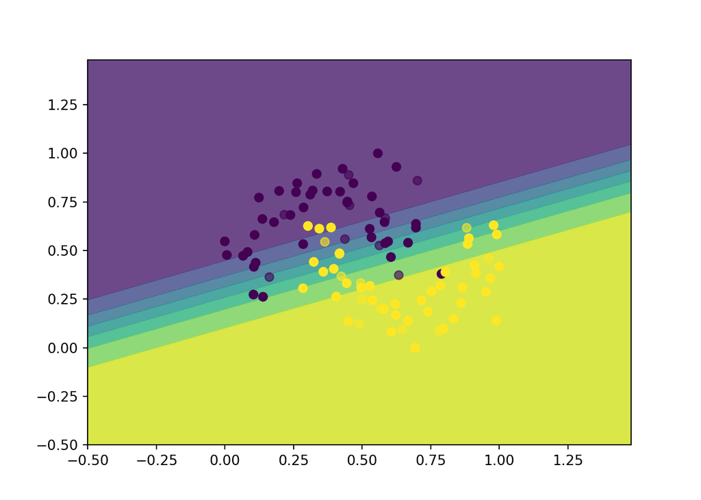

```python
plot_decision_boundary(mlp, (xtrain, ytrain), (xtest, ytest))
```

The score is 0.85. Removing th activation function removes all capability of found relations in the data. The only calculation are summation and multiplication

# 3 Exercise

```python
import pandas as pd
import numpy as np
from sklearn.datasets import load_digits
from sklearn.model_selection import train_test_split
from sklearn.neural_network import MLPClassifier

df = load_digits(n_class=10, as_frame=True)
dir(df)
```

```
['DESCR', 'data', 'feature_names', 'frame', 'images', 'target', 'target_names']
```

```python
x = df.data
y = df.target

xtrain, xtest, ytrain, ytest = train_test_split(x, y, test_size=.3, random_state=42)
```

```python
from sklearn.preprocessing import MinMaxScaler

mms = MinMaxScaler()
xtrain = mms.fit_transform(xtrain)
xtest = mms.transform(xtest)
```

Sklearn understand when the classification is multi class.

```python
mlp = MLPClassifier(
  hidden_layer_sizes=(512, 256, 128),
  activation="relu",
  solver='adam',
  alpha=0.0001,
  batch_size='auto',
  learning_rate='constant',
  learning_rate_init=0.001,
  n_iter_no_change=10,
  verbose=True
)
mlp.fit(xtrain, ytrain)
```

```
MLPClassifier(hidden_layer_sizes=(512, 256, 128), verbose=True)
```

```python
mlp.score(xtest, ytest)
```

```
0.975925925925926
```

```python
weights = 0
for i in range(len(mlp.coefs_)):

  coefs = mlp.coefs_[i].size #.shape[0 as np.arrays]
  bias = mlp.intercepts_[i].size

  tot = coefs+bias

  print(f"Layer {i} => Weights {coefs} Bias {bias} Totale {tot}")

  weights += tot
```

```
Layer 0 => Weights 32768 Bias 512 Totale 33280
Layer 1 => Weights 131072 Bias 256 Totale 131328
Layer 2 => Weights 32768 Bias 128 Totale 32896
Layer 3 => Weights 1280 Bias 10 Totale 1290
```

```python
print(f"Total coefficients of the NN {weights}")
```

```
Total coefficients of the NN 198794
```

```python
ypred = mlp.predict(xtest)
ytrue = ytest

from sklearn.metrics import classification_report

print(classification_report(ypred, ytrue, digits=2))
```

```
              precision    recall  f1-score   support

           0       0.98      0.98      0.98        53
           1       1.00      0.96      0.98        52
           2       1.00      0.94      0.97        50
           3       0.96      0.96      0.96        54
           4       1.00      0.98      0.99        61
           5       0.94      0.97      0.95        64
           6       0.98      0.98      0.98        53
           7       0.98      1.00      0.99        54
           8       0.95      1.00      0.98        41
           9       0.97      0.98      0.97        58

    accuracy                           0.98       540
   macro avg       0.98      0.98      0.98       540
weighted avg       0.98      0.98      0.98       540
```

Lets check where the model is making mistakes.

```python
errors_mask = ypred != ytrue
errors_mask.sum()
```

```
np.int64(13)
```

```python
xerror = xtest[errors_mask]
yerror = ytrue[errors_mask]
yerror_pred = ypred[errors_mask]

yerror = yerror.reset_index(drop=True)
```

```python
plt.close()
fig = plt.figure(figsize=(12, 12))
fig.subplots_adjust(wspace=0)

for i in range(xerror.shape[0]):
  # iterate over n image
  plot = fig.add_subplot(4, 5, i+1)
  plt.imshow(xerror[i, :].reshape(8, 8))
  plt.text(
    0,
    7,
    f"Class {int(yerror[i])}",
    fontsize=12,
    fontdict={"weight":"bold"}
    )
  plt.text(
    0,
    6,
    f"Pred {int(yerror_pred[i])}",
    fontsize=12,
    fontdict={"weight":"bold"}
    )
  plt.axis("off")
```

[output not shown]

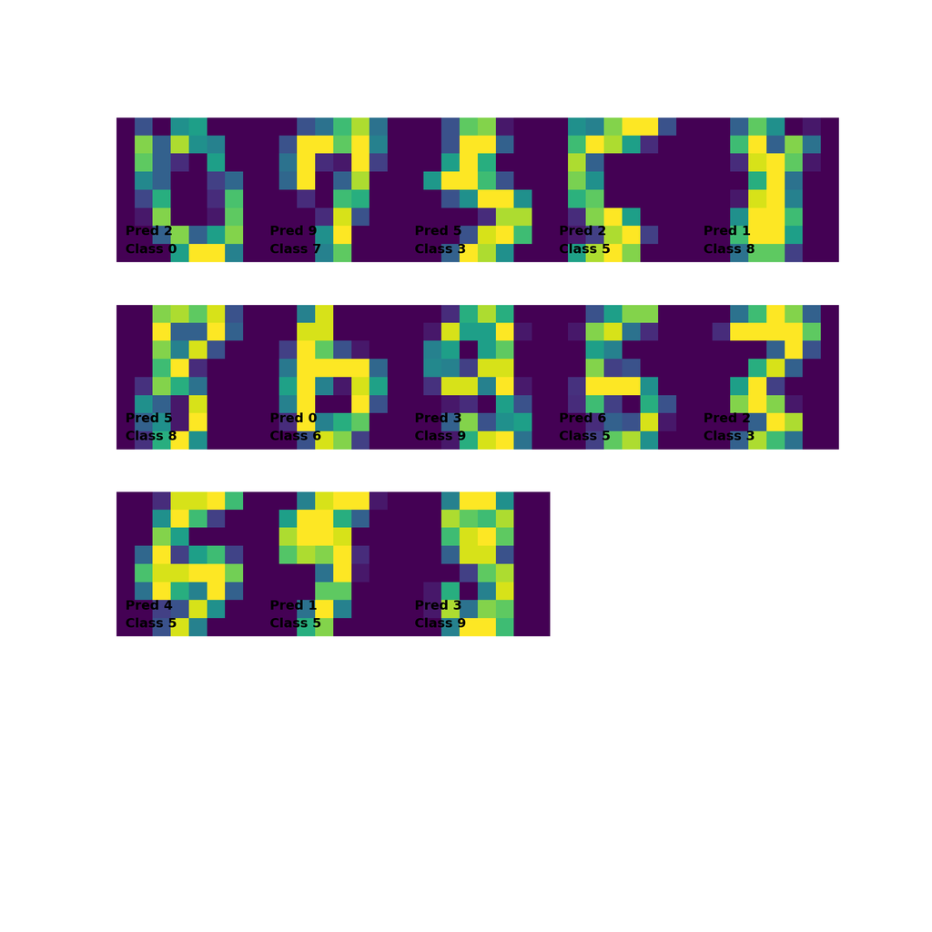

```python
plt.show()
```

But is the MLP the best solution?

```python
from sklearn.linear_model import LogisticRegression

lr = LogisticRegression()
lr.fit(xtrain, ytrain)
```

```
LogisticRegression()
```

```python
lr.score(xtest, ytest)
```

```
0.9666666666666667
```

Considering the result, it could seem a good result, but sometimes is not enough. For example, if used in an autonomous card, it would not be enough.